# Testing Independence between Network and Network

Youjin Lee

- Network vs. Network
- Locally Dependent Model

## Network vs. Network

Assume a network $G$ and $H$ have same node index - maybe they are all considering same individuals but different networks. Someone might be interested in testing independence between online friendship and offline friendship; independence between physical connections and functional relationship, etc.

$H_{0}: f_{GH} = f_{G} f_{H}$

For all nodes $i \neq j$ in a graph $G$, and all nodes $u \neq v$ in a graph $H$, suppose the following latent variable model:

$(X_1, W_1), (X_2, W_2) , ... , (X_N, W_N) \overset{i.i.d}{\sim} N \left( \begin{bmatrix} 0 \\ 0 \end{bmatrix}, \begin{bmatrix}1 & \rho \\ \rho & 1 \end{bmatrix} \right)$

$\log \left( \frac{P\big( T_{ij} \big) }{1 - P\big( T_{ij} \big) } \big| X_i, X_j \right) = f \big( | X_i - X_j | \big) = \log \left( \frac{P\big( T_{uv} \big) }{1 - P\big( T_{uv} \big) } \big|W_i, W_j \right)$

All the simulations below are based on $M = 500$ iterations $n=300$ nodes

1. $\rho = 0.0$

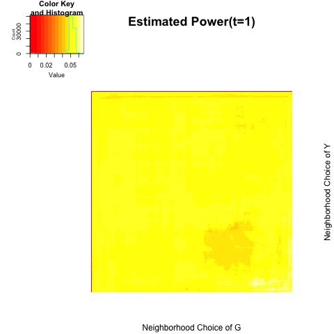

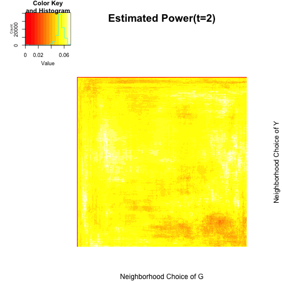

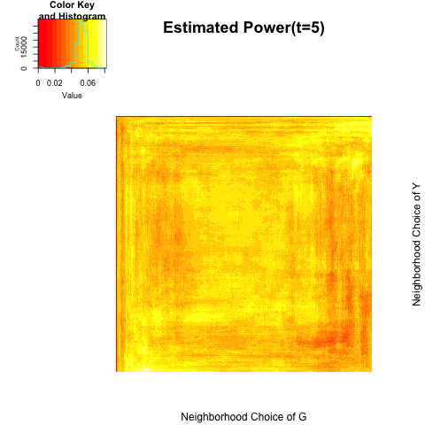

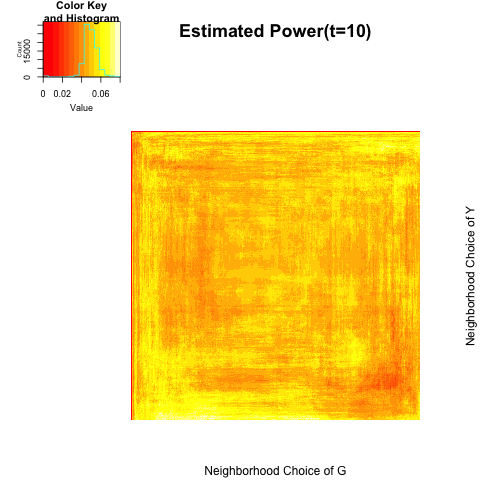

|  | t=1 | t=2 | t=5 | t=10 |
| --- | --- | --- | --- | --- |
| global test | 0.054 | 0.056 | 0.052 | 0.058 |
| local optimal | 0.066 | 0.070 | 0.082 | 0.080 |

2. $\rho = 0.1$

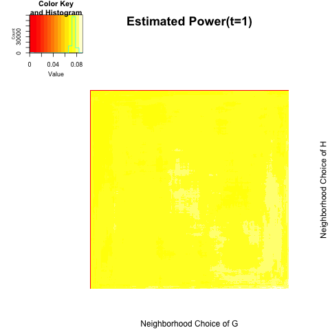

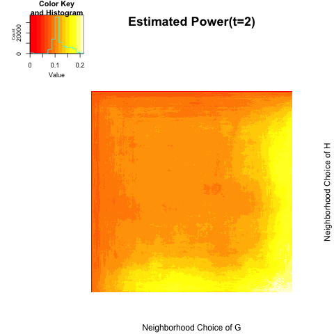

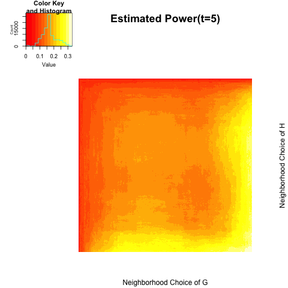

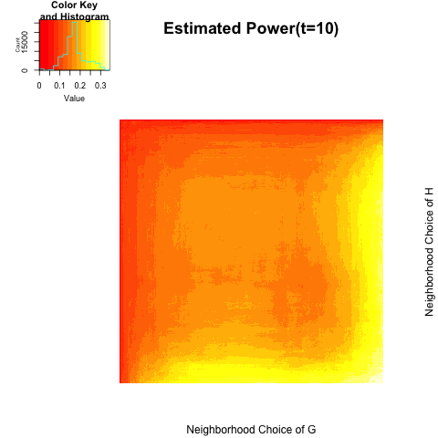

|  | t=1 | t=2 | t=5 | t=10 |
| --- | --- | --- | --- | --- |
| global test | 0.088 | 0.206 | 0.33 | 0.336 |
| local optimal | 0.090 | 0.214 | 0.33 | 0.344 |

3. $\rho = 0.2$

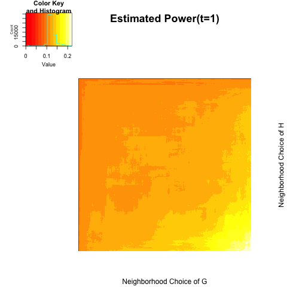

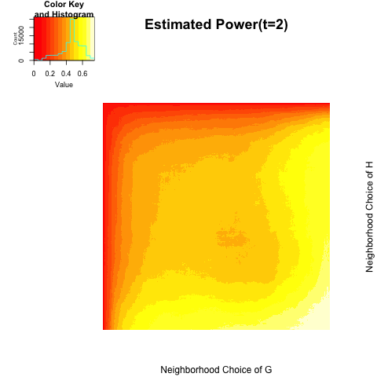

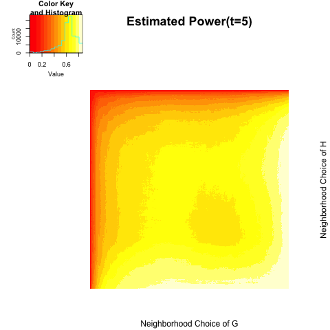

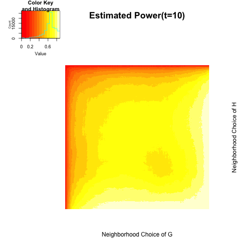

|  | t=1 | t=2 | t=5 | t=10 |
| --- | --- | --- | --- | --- |
| global test | 0.212 | 0.738 | 0.860 | 0.868 |
| local optimal | 0.220 | 0.746 | 0.862 | 0.870 |

## Locally Dependent Model

For each block $i = 1,... , B:$

$(X_{i,1}, W_{i,1}), (X_{i,2}, W_{i,2}) , ... , (X_{i, n_{i}}, W_{i, n_{i}}) \overset{i.i.d}{\sim} N \left( \begin{bmatrix} 0 \\ 0 \end{bmatrix}, \begin{bmatrix}1 & \rho_{i} \\ \rho_{i} & 1 \end{bmatrix} \right)$

$\log \left( \frac{P\big( T_{ij} \big) }{1 - P\big( T_{ij} \big) } \big| X_i, X_j \right) = f \big( | X_i - X_j | \big) = \log \left( \frac{P\big( T_{uv} \big) }{1 - P\big( T_{uv} \big) } \big|W_i, W_j \right)$

1. $B = 2$; ratio = c(1,3); $\rho =(0.3, 0.0);$ $N=300;$ $M =300$